# ptp1b_seurat

```r
library(here)
# Setting the random seed to replicate results
seed <- readRDS(here("results/original_seed.rds"))
assign(".Random.seed", seed, envir = .GlobalEnv)
# Cache results so huge analysis doesn't have to be rerun
knitr::opts_chunk$set(cache = TRUE)
```

## Analyzing the Feature-Barcode Matrix in R

The main output from pre-processing is a matrix quantifying the expression of each gene in each cell. The Seurat package for R includes many tools for analyzing this type of single-cell data.

This analysis will heavily follow the Guided Clustering Tutorial provided on the Seurat website: https://satijalab.org/seurat/articles/pbmc3k_tutorial.html

### Creating a Seurat object from the matrix

I’ll start by loading in the Seurat package. Since the data is in matrix format, I will also use the Matrix package for some easier manipulation. The dplyr package is always helpful for piping commands and moving data around. Ggplot2 is always handy for plotting.

I also came back to this later and added the ‘here’ package. This adds reproducibility by making my file paths relative to the project’s main directory, no matter who is running them. I was using hardcoded paths before that would only work on my own laptop.

```r
library(Seurat)
library(Matrix)
library(dplyr)
library(ggplot2)
library(here)
```

The first step of analysis is reading in the matrix generated by bustools count, after setting my working directory to the output folder from kallisto. Looking at the dimensions of this matrix:

```r
counts <- readMM(here("results/kallisto_output/counts.mtx"))
dim(counts)
```

```
[1] 372063  55335
```

That represents 372,063 possible cell barcodes, and 55,335 genes/transcripts from the reference transcriptome (a high number because this includes many noncoding).

First of all this matrix needs to be transposed, Seurat expects rows to be features and columns to be cell barcodes:

```r
counts <- t(counts)
```

Next I’ll bring in the lists of barcode and feature names:

```r
barcodes <- readLines(here("results/kallisto_output/counts.barcodes.txt"))
features <- readLines(here("results/kallisto_output/counts.genes.txt"))
```

The feature names are currently Ensembl IDs that need the version number removed.

```r
features <- sub("\\.\\d+$", "", features)
```

These lists can be assigned as names to the columns and rows of the matrix:

```r
rownames(counts) <- features
colnames(counts) <- barcodes
```

372k barcodes is an extremely high amount, it’s likely that many of these are empty droplets that don’t actually contain cells. Printing a summary of UMIs supports this conclusion:

```r
summary(colSums(counts))
```

```
   Min. 1st Qu.  Median    Mean 3rd Qu.    Max.
    0.0     1.0     1.0    65.4    25.0 34963.0
```

```r
# colSums(): Adds up the values in each column (# of UMIs for each cell)
# summary(): Computes some basic statistics (mean, median, min, max)
```

The mean is 65.4 while the median is only 1! That means at least half the barcodes only have 1 UMI, a sign of empty droplets. To get rid of these data points, I will filter down to barcodes associated with at least 500 UMIs.

```r
counts_filtered <- counts[, colSums(counts) >= 500]
```

Now the matrix with raw counts can be turned into Seurat’s special data structure, which can store the analysis that I will perform. This step also allows for a bit of additional filtering:

```r
so <- CreateSeuratObject(counts = counts_filtered,
                         project = "ptp1b_ad",
                         min.cells = 3,
                         min.features = 200)
# min.cells: Drop any gene present in less than 3 cells
# min.features: Drop any cell with less than 200 unique features
```

I chose these numbers for filtering as a starting point (they are used in the Seurat walkthrough). There is also more quality control to look at before drawing any conclusions.

### Filtering Low-Quality Cells

I need to remove low-quality cells from this scRNA-seq data. There are a few common ways to filter out low-quality and dying cells, including:

- Low number of total UMIs.  
- Low number of unique genes/features.  
- High percentage of UMIs from mitochondrial genes. (Cytoplasmic RNA is lost first in dying cells, so mitochondria get overrepresented)

The first two are built into the cell metadata that Seurat gives as “nCount_RNA” and “nFeature_RNA,” respectively:

```r
head(so@meta.data, 5)
```

```
                 orig.ident nCount_RNA nFeature_RNA
AAACCCAAGGCAGTCA   ptp1b_ad       5564         2418
AAACCCAAGGTAGACC   ptp1b_ad       1320          819
AAACCCAGTAACTTCG   ptp1b_ad       9056         3323
AAACCCAGTAGTACGG   ptp1b_ad       4755         2236
AAACCCAGTATTGAGA   ptp1b_ad       3766         1634
```

For mitochondrial content, I will need to create a new column alongside these two others.

Finding the mitochondrial genes is a little tricky because everything in the matrix is an Ensembl ID right now. I will have to go back to the annotation file and find out which ones are the mitochondrial genes.

```r
gtf <- read.table(here("data/references/gencode.vM23.annotation.gtf"),
                  sep = "\t",
                  comment.char = "#",
                  header = FALSE)
# sep = "\t": File is tab separated (gtf)
# comment.char = "#": Lines beginning with # are comments
# header = False: No header row in gtf file
```

Mouse mitochondrial genes are listed as being on chromosome “chrM” (column ‘V1’), and genes are the type of feature that I’m looking for (column ‘V3’):

```r
mt.gtf <- gtf[gtf$V1 == "chrM" & gtf$V3 == "gene", ]
# gtf$V1 == "chrM": Mitochondrial chromosome
# gtf$V3 == "gene": Feature type is "gene"
```

Gene IDs are in the attribute field (column ‘V9’) alongside a bunch of other information that will need to be removed:

```r
attr <- mt.gtf$V9
head(attr)
```

```
[1] "gene_id ENSMUSG00000064336.1; gene_type Mt_tRNA; gene_name mt-Tf; level 3; mgi_id MGI:102487;"
[2] "gene_id ENSMUSG00000064337.1; gene_type Mt_rRNA; gene_name mt-Rnr1; level 3; mgi_id MGI:102493;"
[3] "gene_id ENSMUSG00000064338.1; gene_type Mt_tRNA; gene_name mt-Tv; level 3; mgi_id MGI:102472;"
[4] "gene_id ENSMUSG00000064339.1; gene_type Mt_rRNA; gene_name mt-Rnr2; level 3; mgi_id MGI:102492;"
[5] "gene_id ENSMUSG00000064340.1; gene_type Mt_tRNA; gene_name mt-Tl1; level 3; mgi_id MGI:102482;"
[6] "gene_id ENSMUSG00000064341.1; gene_type protein_coding; gene_name mt-Nd1; level 3; mgi_id MGI:101787;"
```

I used AI to write a command with regex that isolates the ID names we need:

```r
# Remove everything except the Ensembl ID
mt.genes <- sub('.*gene_id "?([^";]+)"?.*', '\\1', attr)
# Remove the version number
mt.genes <- sub("\\..*", "", mt.genes)
head(mt.genes)
```

```
[1] "ENSMUSG00000064336" "ENSMUSG00000064337" "ENSMUSG00000064338"
[4] "ENSMUSG00000064339" "ENSMUSG00000064340" "ENSMUSG00000064341"
```

With the list of mitochondrial Ensembl IDs, I can calculate the mitochondrial percentage for each barcode.

```r
so[["percent.mt"]] <- PercentageFeatureSet(so, features = mt.genes)
# so[["percent.mt"]]: Add a new column for mitochondrial percentage
# PercentageFeatureSet(so, pattern = "^mt-"): For each barcode, calculate the percentage of genes starting with "mt-" (mitochondrial)

summary(so$percent.mt)
```

```
   Min. 1st Qu.  Median    Mean 3rd Qu.    Max.
  0.000   1.697   2.485   3.764   4.409  55.330
```

The summary looks like what should be expected! The mean is 3.7% mitochondrial genes.

Let’s inspect all the cell metadata with this new column added:

```r
head(so@meta.data, 5)
```

```
                 orig.ident nCount_RNA nFeature_RNA percent.mt
AAACCCAAGGCAGTCA   ptp1b_ad       5564         2418   2.606039
AAACCCAAGGTAGACC   ptp1b_ad       1320          819  11.969697
AAACCCAGTAACTTCG   ptp1b_ad       9056         3323   1.899293
AAACCCAGTAGTACGG   ptp1b_ad       4755         2236   2.923239
AAACCCAGTATTGAGA   ptp1b_ad       3766         1634   2.097716
```

```r
# @meta.data: Contains cell-level metadata like # of features and UMIs
```

Finally, let’s visualize each of these QC metrics with a violin plot:

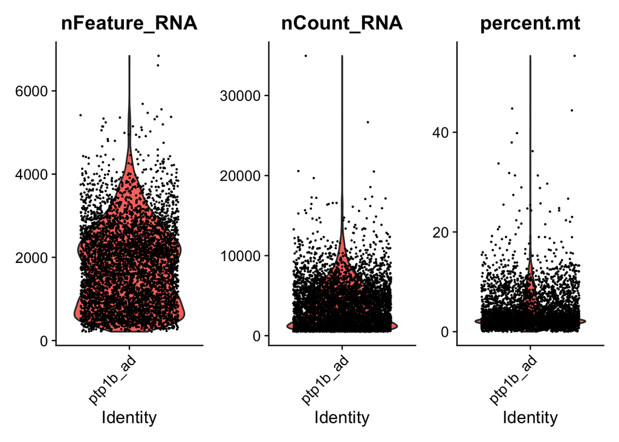

```r
VlnPlot(so, features = c("nFeature_RNA", "nCount_RNA", "percent.mt"), ncol = 3)
```

- nFeatureRNA: The bulk of the violin plot sits at ~500-3500 genes. The outliers towards the top are very likely doublets, where two cells were mistakenly counted as one.
- nCountRNA: Most barcodes sit at <10000 UMIs.
- percent.mt: The majority of cells are grouped up at ~5% mitochondrial content. A tail of outliers goes up as high as 50%.

To help choose cutoffs a FeatureScatter plot is also helpful. These plots show how the number of features and mitochondrial percentage differs based on UMI count:

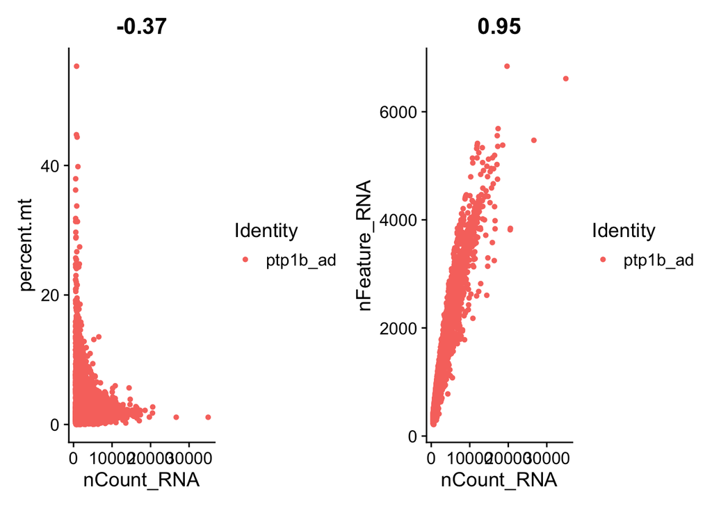

```r
# Plot # of UMIs vs mitochondrial content
plot1 <- FeatureScatter(so, feature1 = "nCount_RNA", feature2 = "percent.mt")

# Plot # of UMIs vs # of features
plot2 <- FeatureScatter(so, feature1 = "nCount_RNA", feature2 = "nFeature_RNA")

plot1 + plot2
```

- nCount_RNA vs percent.mt: Cells with the highest mitochondrial content also have the lowest UMI counts, a result typically expected from dead/dying cells.
- nCount_RNA vs nFeature_RNA: There is 0.95 correlation between UMI count and gene count, which is good! Points that are way to far above have way too many features and are doublet candidates.

Based on these plots I can filter out the outliers and make this data better for analysis. The Seurat tutorial example uses the following numbers:

- 200 < nFeature_RNA < 2500
- percent.mt < 5

Their data is from human cells with different results for the previous figures. Looking at my own plots, it looks like I can be a little more generous and include:

- 200 < nFeature_RNA < 5000
- percent.mt < 15

This will keep the main body of each plot while removing almost all doublets and dead cells. Time to apply these filters to the data:

```r
so <- subset(so, subset = nFeature_RNA > 200 &
                           nFeature_RNA < 5000 &
                           percent.mt < 15)
```

### Normalization

Right now the data is still raw counts, so a cell with more total UMIs will look like it has more expression for each gene. Data is commonly normalized so gene expression is given in proportion to total UMIs:

```r
so <- NormalizeData(so, normalization.method = "LogNormalize", scale.factor = 10000)
```

```
Normalizing layer: counts
```

```r
# LogNormalize: Log transformation (common normalization method, makes exponential relationships linear)
# scale.factor = 10000: Divide counts by total UMIs and multiply by 10000 before transforming.
```

### Identifying Highly Variable Genes

The Seurat tutorial recommends identifying genes with the highest cell-to-cell variation in expression, and focusing on them for downstream analysis. This removes noise from the genes that are expressed the same across all cells. I will follow their steps to create a subset of the 2000 most variable genes in this dataset:

```r
so <- FindVariableFeatures(so, selection.method = "vst", nfeatures = 2000)
```

```
Finding variable features for layer counts
```

```r
# selection.method = "vst": Variance stabilizing transformation (recommended method)
# nfeatures = 2000: Find the 2000 most variable features
```

Now the Seurat object stores this list of variable features. Taking a look at the top 10 gives a list of Ensembl IDs:

```r
top10 <- head(VariableFeatures(so), 10)
top10
```

```
 [1] "ENSMUSG00000061808" "ENSMUSG00000060586" "ENSMUSG00000024610"
 [4] "ENSMUSG00000036594" "ENSMUSG00000026051" "ENSMUSG00000036169"
 [7] "ENSMUSG00000073421" "ENSMUSG00000041378" "ENSMUSG00000017344"
[10] "ENSMUSG00000029304"
```

In order to tell what these genes are I need to use the annotation file once again, as a map. To start I’ll make a subset of all rows with the feature type we are looking for (gene):

```r
gene.gtf <- gtf[gtf$V3 == "gene",]
# gtf$V3 == "gene": All rows with "gene" as feature type
# Leave blank after the comma to keep all columns
```

The names and IDs of all these genes are found in the attributes column (column 9), and can be extracted with some more regex magic. The version numbers also need to be removed from these Ensembl IDs as I did earlier.

This information can build a new data frame mapping Ensembl IDs to their actual gene names:

```r
gene.ids   <- sub('.*gene_id "?([^";]+)"?.*',   '\\1', gene.gtf$V9)
gene.ids <- sub("\\.\\d+$", "", gene.ids)

gene.names <- sub('.*gene_name "?([^";]+)"?.*', '\\1', gene.gtf$V9)

gene.map <- data.frame(ensembl_id = gene.ids,
                       gene_name  = gene.names)
```

Now the list of top 10 variable genes is identified:

```r
gene.map[gene.map$ensembl_id %in% top10, ]
```

```
              ensembl_id gene_name
657   ENSMUSG00000026051     Ecrg4
14818 ENSMUSG00000029304      Spp1
33699 ENSMUSG00000017344       Vtn
35657 ENSMUSG00000036169   Sostdc1
44754 ENSMUSG00000041378     Cldn5
47040 ENSMUSG00000073421    H2-Ab1
47041 ENSMUSG00000036594     H2-Aa
47043 ENSMUSG00000060586    H2-Eb1
48562 ENSMUSG00000061808       Ttr
49219 ENSMUSG00000024610      Cd74
```

```r
# gene.map[]: Return a subset of the gene map
# gene.map$ensembl_id %in% top10: Only return IDs that are in the top 10 list
```

It’s also a good time to go ahead and switch all the Ensembl IDs for their corresponding gene names, so downstream results will be much easier to interpret:

```r
new.names <- gene.map$gene_name[match(rownames(so), gene.map$ensembl_id)]
# new.names <- gene.map$gene_name[...]: New vector containing the gene symbol at each position listed in brackets
# match(rownames(so), gene.map$ensembl_id): Position in the gene map for each gene ID in the Seurat object

rownames(so[["RNA"]]) <- make.unique(new.names)
# rownames(so[["RNA"]]): Update gene names in the Seurat object
# make.unique(new.names): For multiple transcripts from the same gene, give each row a unique name (required by R)
```

Rerunning the variable feature search so the list of top 2,000 features has these updated names:

```r
so <- FindVariableFeatures(so, selection.method = "vst", nfeatures = 2000)
```

```
Finding variable features for layer counts
```

```r
top10 <- head(VariableFeatures(so), 10)
```

Now all of the features can be plotted as a VariableFeaturePlot:

```r
# Creating a variable feature plot
plot1 <- VariableFeaturePlot(so)

# Labeling the top 10 variably expressed genes
plot2 <- LabelPoints(plot = plot1, points = top10, repel = TRUE)
```

```
When using repel, set xnudge and ynudge to 0 for optimal results
```

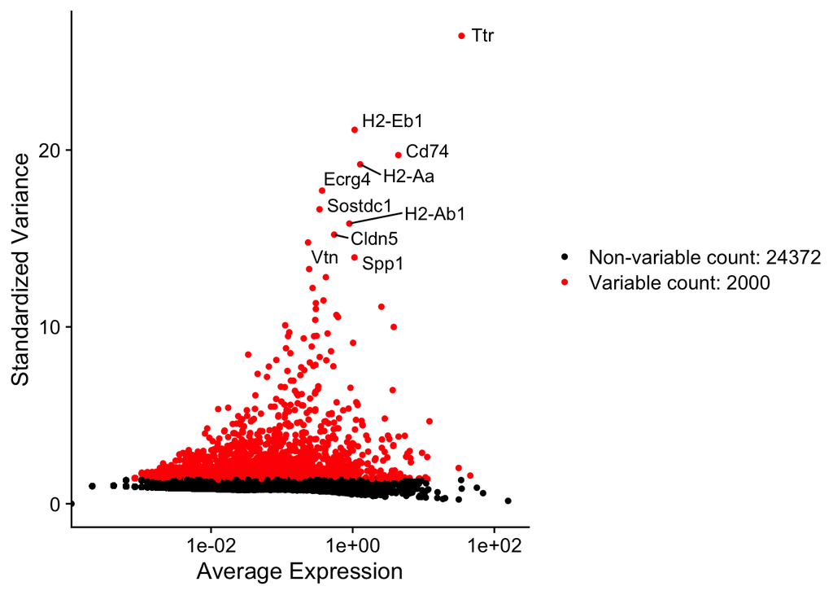

```r
plot2
```

In this plot the x-axis shows the average (normalized) expression of each gene, while the y-axis shows how much this expression varies across cells. The black dots on the bottom are deemed not variable while all genes above a certain threshold are called variable. The most variable genes are the top 10, with labeled points!

### Scaling / PCA

The next goal is to do a PCA, which condenses all of these variables down to a few principal components. This clearly separates clusters of cells based on how they express these 2,000 variable genes relative to one another. Ideally these separations will reflect underlying biology such as different cell types.

Similar to the normalization performed earlier, the data has to be scaled before proceeding as some genes are naturally expressed much more highly than others. For example, a widely used housekeeping gene will show much more expression across all cells versus a rarely used transcription factor. Scaling ensures that the principal components are not dominated by genes with a higher overall magnitude of expression.

```r
all.genes <- rownames(so)
# rownames(so): List of all genes in the Seurat object

so <- ScaleData(so, features = all.genes)
# ScaleData: Scales and centers all features in the data set
```

Now it’s time to run the PCA with the variable features that were identified:

```r
so <- RunPCA(so, features = VariableFeatures(so))
```

```
PC_ 1
Positive:  Laptm5, Cyba, H2-K1, Ctss, B2m, Cd52, H2-D1, Ly6e, C1qc, C1qa
       C1qb, Fcer1g, Selplg, Hexb, Ly86, Tyrobp, Trem2, Cx3cr1, Cd53, Csf1r
       Ptpn18, Ptprc, Gpr34, Rgs10, Ctsd, Fyb, H2-T23, Ctsh, Cyth4, Coro1a
Negative:  Ptn, Htra1, S100a16, Car2, Fez1, Olig1, Ndrg2, Plpp3, Gstm5, Enpp2
       Cryab, Acsl3, Mal, Ttyh1, Tuba1a, Stmn4, Slc6a1, Cldn11, Nrxn1, Dtna
       Il33, Gm21984, Mog, Dclk1, Stmn1, Cspg5, Tubb4a, Apod, Ugt8a, Tspan2
PC_ 2
Positive:  Mal, Cldn11, Mog, Mobp, Gm21984, Apod, Stmn4, Ermn, Tubb4a, Tspan2
       Ppp1r14a, Qdpr, Enpp2, Ptgds, Opalin, Cryab, Ugt8a, Pex5l, Nkx6-2, Car2
       Ndrg1, Stmn1, Il33, Grb14, Lpar1, Fez1, Anln, Hapln2, Elavl3, Gnai1
Negative:  Gpr37l1, Ptprz1, Bcan, Gpm6a, Sparcl1, Atp1a2, Nrxn1, Cspg5, Ntrk2, Gm3764
       Gria2, F3, Atp1b2, Ntsr2, Lsamp, Slc1a2, Slc4a4, Pla2g7, Gja1, Mmd2
       Mfge8, Tril, S1pr1, Fjx1, Clu, Slc6a11, Slc7a10, Cxcl14, Ntm, Fgfr3
PC_ 3
Positive:  Cd3g, Ms4a4b, Trbc2, Cd3e, Nkg7, Cxcr6, Cd3d, Gimap3, Gimap4, Ltb
       Ctsw, Ptprcap, Ccl5, S100a10, AW112010, Trac, Gimap7, Lck, Skap1, Ly6a
       Thy1, S100a11, Cd2, S100a6, Lat, Cd8a, Gimap1, Cd226, Hcst, Fxyd5
Negative:  Lgmn, C1qc, C1qb, C1qa, Hexb, Trem2, Ly86, Csf1r, Cx3cr1, Ctsz
       Cst3, Ctsl, Tyrobp, Fcer1g, Ctss, Gpr34, P2ry12, Ctsb, Siglech, Olfml3
       Fcrls, Itgb5, Cd68, Grn, Fcgr3, Cd300c2, Hexa, Mpeg1, Unc93b1, Lair1
PC_ 4
Positive:  Cd3g, Bcl2, Ms4a4b, Nkg7, Cxcr6, Cd3d, Ltb, Cd3e, Trbc2, Ntsr2
       Gimap3, Ccl5, Slc1a2, Ptprcap, Ctsw, Gimap4, Trac, Gimap7, Gm3764, Hcst
       Lck, Slc6a11, Skap1, Gpr37l1, Slc4a4, Thy1, Cldn10, Fgfr3, Pla2g7, Cd8a
Negative:  Cldn5, Slco1a4, Ly6c1, Itm2a, Adgrl4, Pltp, Ptprb, Egfl7, Flt1, Igfbp7
       Spock2, Hspb1, Adgrf5, Cxcl12, Abcb1a, Esam, Jcad, Emcn, Foxq1, Sema3c
       Ramp2, Cdh5, Klf2, Sox18, Wfdc1, Tm4sf1, Pcp4l1, Fn1, Podxl, Slc7a5
PC_ 5
Positive:  S1pr1, Slco1c1, Gja1, Prex2, Ntsr2, Fgfr3, Slc6a11, Gm6145, Cldn10, Slc4a4
       Grin2c, Gjb6, Aqp4, Mfge8, Acsl6, Slc39a12, Nwd1, Mlc1, Cldn5, Acsl3
       Fam107a, Pla2g7, Cxcl14, Ly6c1, Slc1a2, Slc7a11, Mt2, Ccdc141, Slc1a3, Acsbg1
Negative:  Ly6h, Rtn1, Meg3, Stmn3, Fxyd6, Bex1, Bex2, Chgb, Reln, 6330403K07Rik
       Syt1, Cacna2d2, Snhg11, Podxl2, C1ql1, Gap43, Elavl4, Opcml, Nhlh2, Olfm2
       Lhfpl3, Clstn2, Slc17a6, Pdgfra, Cit, Ndn, Ndnf, Nxph1, Gng3, Olfm1
```

This output gives a list of the principal components that were created, and which genes are positively or negatively associated with each.

To see the hierarchy of PCs and figure out which ones are most worth using, an elbow plot is used:

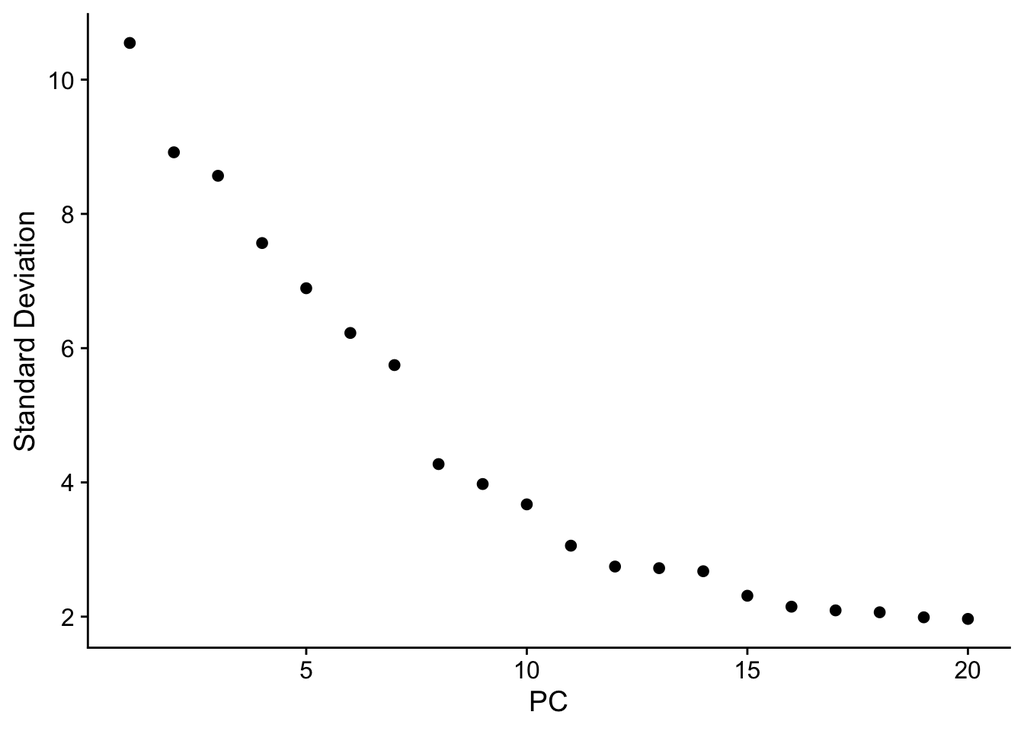

```r
ElbowPlot(so)
```

The x-axis is the list of PCs from highest to lowest standard deviation, which is given on the y-axis. A higher standard deviation indicates more variance being represented by that PC.

Where there are big drops in standard deviation, we can say that the PCs are capturing meaningful variation. The “elbow” is where the curve flattens out and PCs are no longer different in a way that is meaningful. To be extra safe, I will include PC1-15 for the rest of the analysis. After these results, the standard deviation becomes extremely low.

### Clustering

Clustering the cells is done using two commands. FindNeighbors identifies cells with similar expression profiles across all 15 PCs and assigns “neighborhoods,” connecting them together. FindClusters is what actually assigns each cell to a cluster.

```r
so <- FindNeighbors(so, dims = 1:15)
# dims = 1:15: Use principal components 1-15 as dimensions

so <- FindClusters(so, resolution = 0.5)
```

```
Modularity Optimizer version 1.3.0 by Ludo Waltman and Nees Jan van Eck

Number of nodes: 4755
Number of edges: 168554

Running Louvain algorithm...
Maximum modularity in 10 random starts: 0.9292
Number of communities: 15
Elapsed time: 0 seconds
```

```r
# resolution = 0.5: Controls the number of clusters, 0.5 is starting point used in the Seurat tutorial
```

All 15 dimensions (PCs) need to be condensed down into 2 dimensions to make a readable plot of the clusters. This is done with the UMAP command, and the figure is generated as a dimensional reduction plot:

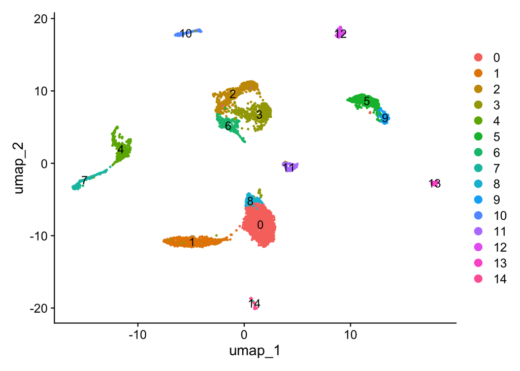

```r
so <- RunUMAP(so, dims = 1:15)
DimPlot(so, reduction = "umap", label = TRUE)
```

This plot shows the relationship of the 15 clusters to one another. The next step is to figure out what these clusters actually are by looking at marker genes. The genes that are most highly expressed in a cluster indicate what type of cells or transcriptional states are present.

Seurat provides a command to find the marker genes. For assigning identities to clusters, I am interested in which genes are being positively expressed relative to everything else:

```r
so.markers <- FindAllMarkers(so, only.pos = TRUE)
# only.pos = TRUE: Only return positively expressed marker genes

head(so.markers)
```

```
         p_val avg_log2FC pct.1 pct.2 p_val_adj cluster     gene
Nkx6-2       0   3.088461 0.967 0.135         0       0   Nkx6-2
Ermn         0   2.892816 0.999 0.184         0       0     Ermn
Opalin       0   3.167590 0.983 0.185         0       0   Opalin
Slain1       0   2.687706 0.950 0.152         0       0   Slain1
Ppp1r14a     0   3.054533 0.994 0.199         0       0 Ppp1r14a
Mog          0   2.235695 0.996 0.220         0       0      Mog
```

The average log2 fold change (“avg_log2FC”) measures how much more a gene is expressed in one cluster compared to the others. Looking through the top 5 overexpressed genes in each cluster is a good starting point:

```r
top5 <- so.markers %>%
  group_by(cluster) %>%
  slice_max(n = 5, order_by = avg_log2FC)
# group_by(cluster): Group the rows by cluster
# slice_max(n = 5): Take the top 5 rows
# order_by = avg_log2FC: Rank rows by highest average log2 fold change

top5
```

```
# A tibble: 75 × 7
# Groups:   cluster [15]
      p_val avg_log2FC pct.1 pct.2 p_val_adj cluster gene
      <dbl>      <dbl> <dbl> <dbl>     <dbl> <fct>   <chr>
 1 7.50e-11       6.10 0.013 0      1.98e- 6 0       Col17a1
 2 3.70e-13       4.85 0.018 0.001  9.76e- 9 0       Tmem210
 3 1.64e-14       4.22 0.02  0.001  4.33e-10 0       Olfr1454
 4 3.18e-14       3.99 0.022 0.001  8.39e-10 0       9330198N18Rik
 5 1.82e-12       3.98 0.017 0.001  4.81e- 8 0       Lctl
 6 3.71e- 7       5.63 0.012 0.001  9.78e- 3 1       Gm17797
 7 6.78e- 6       5.55 0.01  0.001  1.79e- 1 1       1700111E14Rik
 8 1.05e-11       4.97 0.022 0.002  2.78e- 7 1       Gm7452
 9 5.49e- 7       4.96 0.013 0.001  1.45e- 2 1       Gm5862
10 1.93e-15       4.91 0.035 0.004  5.09e-11 1       Gm21680
# ℹ 65 more rows
```

Visualizing some of this expression with a heatmap:

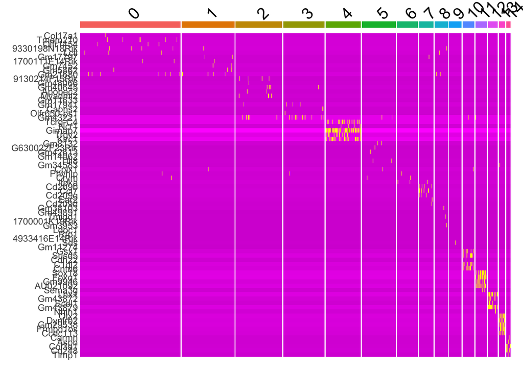

```r
DoHeatmap(so, features = top5$gene) + NoLegend()
```

The yellow blocks indicate cells with high expression of a marker gene. Clusters where the marker genes have a strong presence across the cells can be annotated more confidently, while clusters where the marker genes are barely expressed will be more uncertain.

### Assigning Identity to Clusters

The CellMarker website allows you to look up marker genes by name, and see their distribution in different tissues/cell types: http://www.bio-bigdata.center/CellMarkerBrowse.jsp

But before jumping into that, a good starting point for identifying the clusters is automatic annotation. This utilizes programs that compare the data from these cells to a reference dataset with known labels. The result is a head start on identifying clusters that can then be manually checked.

For this analysis I’m going to try automatic annotation with SingleR. This requires a new library and the celldex library containing reference datasets:

```r
library(SingleR)
library(celldex)
```

In this case, I need the dataset for mouse RNA-seq.

```r
ref <- celldex::MouseRNAseqData()
```

```
see ?celldex and browseVignettes('celldex') for documentation
```

```
loading from cache
```

```
see ?celldex and browseVignettes('celldex') for documentation
```

```
loading from cache
```

SingleR uses the raw UMI counts from the Seurat object. The most important thing it generates is a vector of cell type predictions:

```r
counts.singleR <- GetAssayData(so, layer = "counts")
# GetAssayData(): Extract a layer of data from the Seurat object
# layer = "counts": Raw UMI counts

pred <- SingleR(test = counts.singleR, ref = ref, labels = ref$label.main)
# test = counts.singleR: Data to annotate
# ref = ref: Reference dataset
# labels = ref$label.main: Chooses column from the reference to use as labels. This can be 'main' or 'fine.'

head(pred$labels, 10)
```

```
 [1] "Oligodendrocytes" "Oligodendrocytes" "Oligodendrocytes" "Oligodendrocytes"
 [5] "T cells"          "Epithelial cells" "Oligodendrocytes" "Oligodendrocytes"
 [9] "Oligodendrocytes" "Astrocytes"
```

Let’s add these labels to the Seurat object, and then use them to plot again:

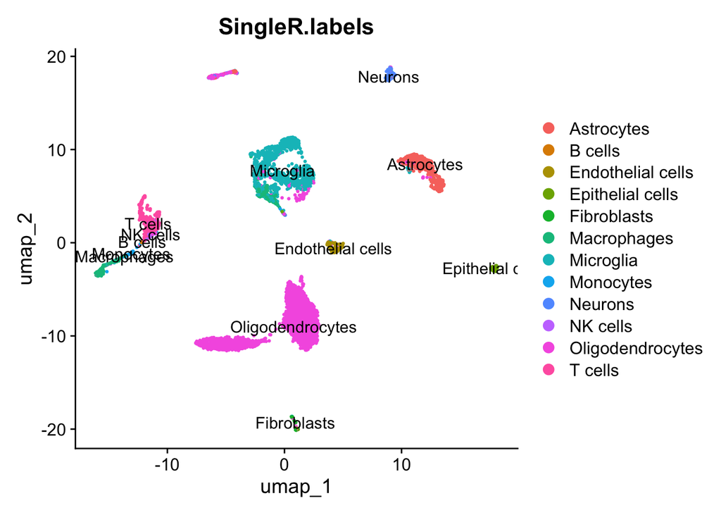

```r
so$SingleR.labels <- pred$labels

DimPlot(so, group.by = "SingleR.labels", reduction = "umap", label = TRUE)
```

Now the clusters are labeled with cell type predictions. I can start checking out the expression of one gene in different cell types, like this:

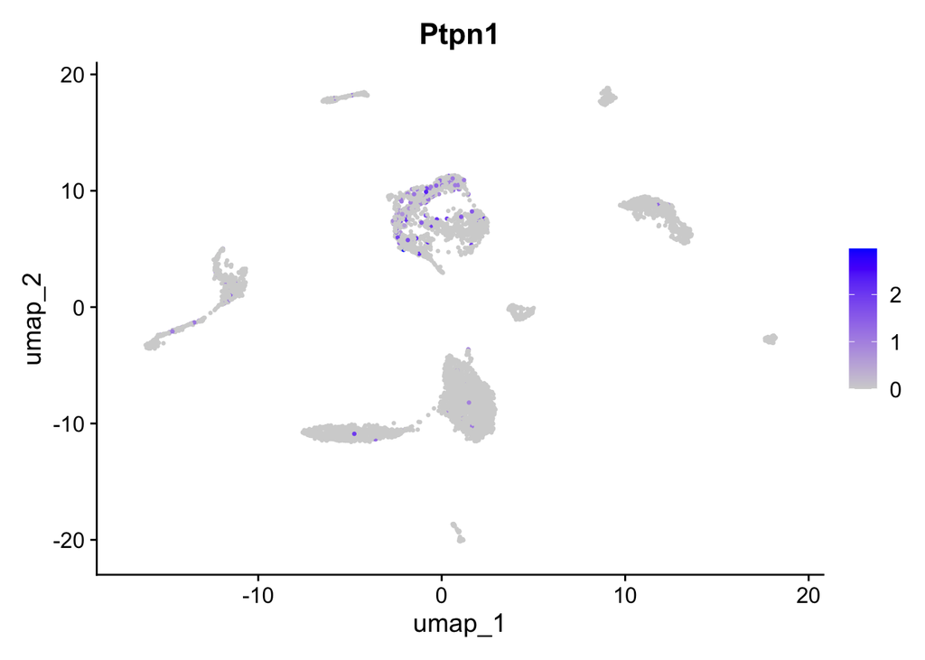

```r
FeaturePlot(so, features = "Ptpn1")
```

This is also how I can start manually annotating the clusters. For example, cluster 12 was predicted to be neurons by SingleR. Looking at a marker gene for neurons, Snap25:

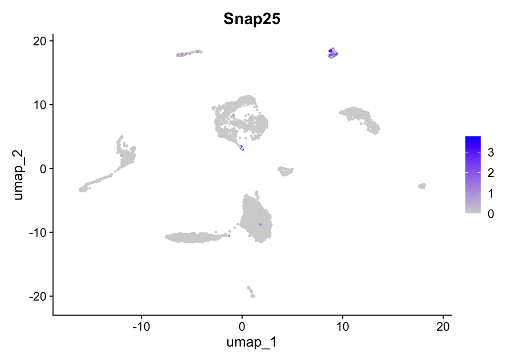

```r
FeaturePlot(so, features = "Snap25")
```

It is most expressed in cluster 12! Manually annotating the clusters with marker genes is the best way to verify these results. Markers can come from knowledge/experience and can also be found in many online resources. In this case a heatmap in the paper’s supplemental info (Fig.S4B) describes which markers were used.

At this point, I’m going to figure out how to bring in the other samples to enable comparison between treatment groups.